# LM with One Predictor

Yan Zhu

2023-10-02

# Set Up

## Read in the data

Read and convert variable names to snake case, and get summary statistics for each of the columns included in the dataframe.

```r
d_raw <- read_excel("/Users/yan/Desktop/sample_code/Design and Analysis of Psychological Experiments/Data/Week_4_data.xlsx", sheet = 1) %>%
  janitor::clean_names()

summary(d_raw)
```

```
##        id             cons1              cons2              cons3
##  Min.   :   1.0   Min.   :   1.000   Min.   :   1.000   Min.   :   1.000
##  1st Qu.: 494.2   1st Qu.:   2.000   1st Qu.:   2.000   1st Qu.:   1.000
##  Median : 987.5   Median :   3.000   Median :   3.000   Median :   2.000
##  Mean   : 987.5   Mean   :   5.457   Mean   :   5.425   Mean   :   5.056
##  3rd Qu.:1480.8   3rd Qu.:   4.000   3rd Qu.:   4.000   3rd Qu.:   4.000
##  Max.   :1974.0   Max.   :5000.000   Max.   :5000.000   Max.   :5000.000
##                   NA's   :44         NA's   :45         NA's   :44
##      cons4              cons5              cons6              cons7
##  Min.   :   1.000   Min.   :   1.000   Min.   :   1.000   Min.   :   1.000
##  1st Qu.:   2.000   1st Qu.:   2.000   1st Qu.:   2.000   1st Qu.:   1.000
##  Median :   3.000   Median :   3.000   Median :   3.000   Median :   3.000
##  Mean   :   5.261   Mean   :   5.412   Mean   :   5.378   Mean   :   5.241
##  3rd Qu.:   4.000   3rd Qu.:   4.000   3rd Qu.:   4.000   3rd Qu.:   4.000
##  Max.   :5000.000   Max.   :5000.000   Max.   :5000.000   Max.   :5000.000
##  NA's   :44         NA's   :46         NA's   :46         NA's   :45
##      cons8              cons9              cons10             cons11
##  Min.   :   1.000   Min.   :   1.000   Min.   :   1.000   Min.   :   1.00
##  1st Qu.:   2.000   1st Qu.:   1.000   1st Qu.:   2.000   1st Qu.:   2.00
##  Median :   3.000   Median :   2.000   Median :   3.000   Median :   3.00
##  Mean   :   5.428   Mean   :   5.065   Mean   :   5.747   Mean   :   5.53
##  3rd Qu.:   4.000   3rd Qu.:   4.000   3rd Qu.:   4.000   3rd Qu.:   4.00
##  Max.   :5000.000   Max.   :5000.000   Max.   :5000.000   Max.   :5000.00
##  NA's   :45         NA's   :45         NA's   :45         NA's   :45
##      cons12             cons13             cons14             cons15
##  Min.   :   1.000   Min.   :   1.000   Min.   :   1.000   Min.   :   1.000
##  1st Qu.:   2.000   1st Qu.:   1.000   1st Qu.:   2.000   1st Qu.:   3.000
##  Median :   3.000   Median :   2.000   Median :   3.000   Median :   4.000
##  Mean   :   5.363   Mean   :   5.106   Mean   :   5.403   Mean   :   6.226
##  3rd Qu.:   4.000   3rd Qu.:   4.000   3rd Qu.:   4.000   3rd Qu.:   5.000
##  Max.   :5000.000   Max.   :5000.000   Max.   :5000.000   Max.   :5000.000
##  NA's   :45         NA's   :45         NA's   :44         NA's   :44
##   social_media  annoying_variable     age                 anx1
##  Min.   :1.00   Min.   :1         Length:1974        Min.   :   1.000
##  1st Qu.:1.00   1st Qu.:1         Class :character   1st Qu.:   1.000
##  Median :1.00   Median :1         Mode  :character   Median :   2.000
##  Mean   :1.48   Mean   :1                            Mean   :   5.056
##  3rd Qu.:2.00   3rd Qu.:1                            3rd Qu.:   4.000
##  Max.   :2.00   Max.   :1                            Max.   :5000.000
##                                                      NA's   :30
```

[output cut: 9 more lines]

```
##  Min.   :1.000   Length:1974        Length:1974        Length:1974
##  1st Qu.:1.000   Class :character   Class :character   Class :character
##  Median :1.000   Mode  :character   Mode  :character   Mode  :character
##  Mean   :1.413
##  3rd Qu.:2.000
##  Max.   :4.000
##  NA's   :44
##    anes_ind
##  Length:1974
##  Class :character
##  Mode  :character
##
##
##
##
```

*hmmm… that’s odd, some of my variables have minimum and maximum values of -5000 and 5000 and means greater than the highest possible value on the scale. I should probably find out what’s happening. It also looks like some of my variables are character class even though I expected them to be numeric. I will have to change that before I work with those variables.*

## Clean Data

**Removing rows**

I have looked at my d_raw dataframe and sorted from low to high and then high to low. It seems there is just 1 participant that has values of 5000 and -5000 for certain variables. I don’t know what is happening with them, so I will remove them from the data file. I will use bracket notation to remove this participant.

```r
d_raw <- d_raw[-(id = 581),]
```

**Remove Variables**

Notice that there is a variable that we do not need for these analyses (labeled AnnoyingVariable). Using bracket notation, remove this variable while also putting the remaining variables (columns) in an order that makes sense to you. Run a command that shows the names of the variables that are left.

```r
d <- d_raw[, c("id", "cons1", "cons2", "cons3", "cons4", "cons5", "cons6", "cons7",
               "cons8", "cons9", "cons10", "cons11", "cons12", "cons13", "cons14",
               "cons15", "social_media", "anx1", "anx2", "anx3", "anx4", "anx5", "age",
               "gender", "anes_0", "anes_rep", "anes_ind", "anes_dem")]
names(d)
```

```
##  [1] "id"           "cons1"        "cons2"        "cons3"        "cons4"
##  [6] "cons5"        "cons6"        "cons7"        "cons8"        "cons9"
## [11] "cons10"       "cons11"       "cons12"       "cons13"       "cons14"
## [16] "cons15"       "social_media" "anx1"         "anx2"         "anx3"
## [21] "anx4"         "anx5"         "age"          "gender"       "anes_0"
## [26] "anes_rep"     "anes_ind"     "anes_dem"
```

*I arranged my variables to start with participant id, then the outcome variable, then the predictors, and then the demographics. I also rearranged the anes items so that the three columns I need to combine are arranged corresponding to their numeric values.*

# Data Preparation

Prepare my two predictor variables and my outcome variable for data analysis. To do so, create composite scores for participant’s belief in conspiracy theory scores and anxiety scores. Do not include any participant in a composite score if they have missed more than 1/3 of the response items for a variable. While it will not affect my interpretation of b1, later in the homework we will ask you to interpret b0. For the sake of easier interpretation of b0, recode social media use age -0.5 (does not use social media) and 0.5 (uses social media).

```r
### outcome: Belief in conspiracies
cons <- paste0("cons", c(1:15))
# psych::alpha(d[, cons])
d$cons_m <- varScore(d,
                     Forward = cons,
                     Reverse = NULL,
                     Range = c(1, 5),
                     Prorate = TRUE,
                     MaxMiss = 1/3) /15


### Predictor: Anxiety
# psych::alpha(d[, c('anx1', 'anx2', 'anx3')], keys = c('anx4', 'anx5'))
d$anx_m <- varScore(d,
                   Forward = c('anx1', 'anx2', 'anx3'),
                   Reverse = c('anx4', 'anx5'),
                   Range=c(1, 5),
                   MaxMiss=1/3,
                   Prorate=T) / 5


### Predictor: Social media
d$social_media_c <- dplyr::recode(d$social_media, "1" = -0.5, "2" = 0.5)
```

Make two quick and dirty plots exploring our main questions: Do anxiety or social media predict the belief in conspiracy theories?.

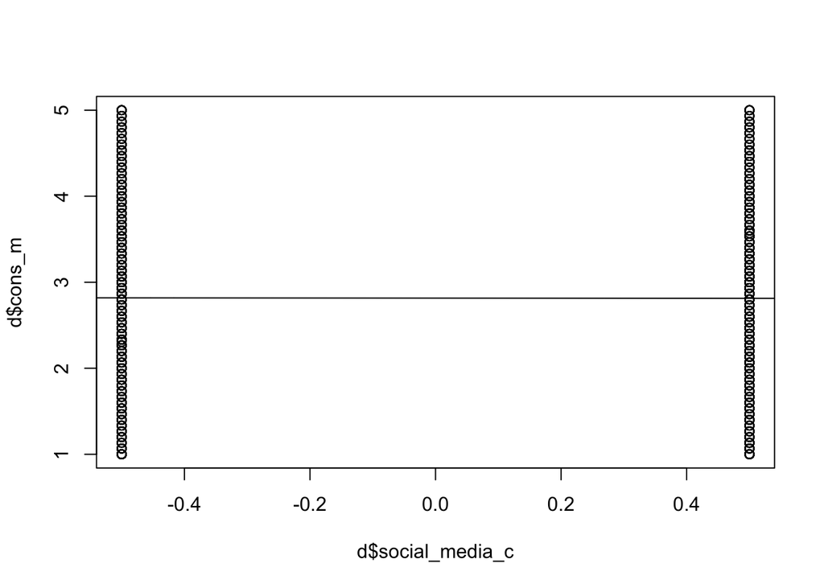

```
## integer(0)
```

```r
plot(d$social_media_c, d$cons_m) + abline(lm(d$cons_m ~ d$social_media_c))
```

*Not the most informative graph, but I can tell any relationship is weak*

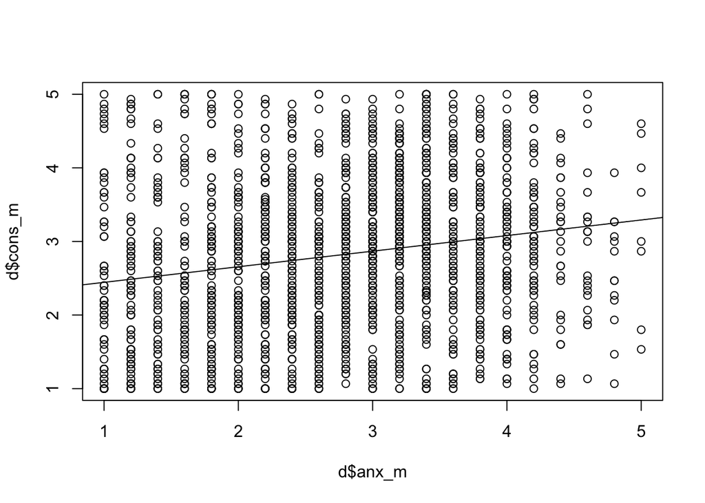

```
## integer(0)
```

```r
plot(d$anx_m, d$cons_m) + abline(lm(d$cons_m ~ d$anx_m))
```

# linear model 1

Fit a linear model to determine if anxiety predicts the belief in conspiracy theories. Report the corresponding (b1) parameter estimate, F-statistic, df, p-value, and Partial eta square. Provide a 95% confidence interval for the (b1) parameter estimate. *b1 = 0.2122; F(1,1926) = 70.54, p < 0.001, partial eta-square = 0.04；95% confidence: [0.1626642, 0.2617723]*

```r
m1 <- lm(cons_m ~ anx_m, d)

(mod_sum = summary(m1)) # b0 = 2.23, b1 = 0.21, p-value < 0.001, F(1,1926) = 70.54
```

```
##
## Call:
## lm(formula = cons_m ~ anx_m, data = d)
##
## Residuals:
##      Min       1Q   Median       3Q      Max
## -2.18392 -0.76548  0.01319  0.69497  2.55584
##
## Coefficients:
##             Estimate Std. Error t value Pr(>|t|)
## (Intercept)  2.23194    0.07334  30.435   <2e-16 ***
## anx_m        0.21222    0.02527   8.399   <2e-16 ***
## ---
## Signif. codes:  0 '***' 0.001 '**' 0.01 '*' 0.05 '.' 0.1 ' ' 1
##
## Residual standard error: 1.016 on 1926 degrees of freedom
##   (45 observations deleted due to missingness)
## Multiple R-squared:  0.03533,    Adjusted R-squared:  0.03483
## F-statistic: 70.54 on 1 and 1926 DF,  p-value: < 2.2e-16
```

```r
mod_sum$coefficients[,"t value"]^2 # F = 70.54
```

```
## (Intercept)       anx_m
##   926.27474    70.54218
```

```r
car::Anova(m1, type = 3) %>% eta_squared()
```

```
## For one-way between subjects designs, partial eta squared is equivalent
##   to eta squared. Returning eta squared.
```

```
## # Effect Size for ANOVA
##
## Parameter | Eta2 |       95% CI
## -------------------------------
## anx_m     | 0.04 | [0.02, 1.00]
##
## - One-sided CIs: upper bound fixed at [1.00].
```

```r
# The results indicate that anx_m explains about 4% of the variance in cons_m.
# This is considered a small to moderate effect size.

confint(m1) # 95% confidence: [0.1626642, 0.2617723]
```

```
##                 2.5 %    97.5 %
## (Intercept) 2.0881132 2.3757624
## anx_m       0.1626642 0.2617723
```

*b1=0.21,F(1,1926)=70.54,p<.001,η2p=0.04, 95% confidence interval: [0.16, 0.26]*

## A publication-quality graph

That depicts the model that I fit(m1 <- lm(cons_m ~ anx_m, d)).

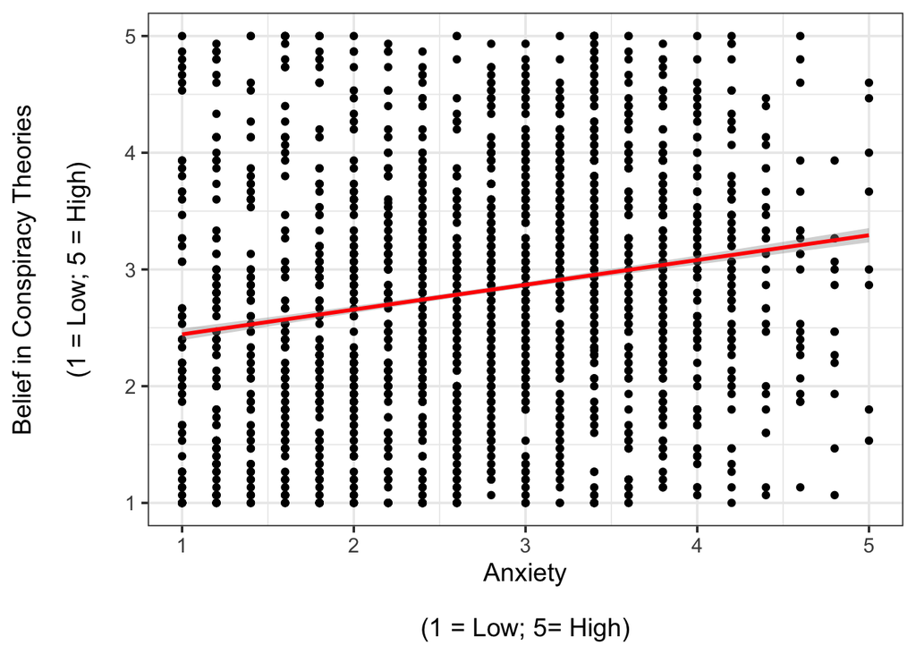

```r
d_graph <- data.frame(anx_m = seq(1, 5, length = 100))
d_graph <- ggplotPredict(m1, d_graph)

p1 <- ggplot(data = d, aes(x = anx_m, y = cons_m)) +
  geom_point() +
  geom_smooth(data = d_graph, aes(ymin = CILo, ymax = CIHi, x = anx_m, y =Predicted),
              stat = "identity", color="red") +
  theme_bw(base_size = 14) +
  labs(x = 'Anxiety\n\n(1 = Low; 5= High)', y = 'Belief in Conspiracy Theories\n\n(1 = Low; 5 = High)\n')

p1
```